# Mixed models excercises part 3

Epidemiology and Big Data

Rebecca Stellato

## Technical issues in mixed models

During this computer lab we will 1) Try to reproduce some results from the second lecture. 2) Revisit examples from earlier in the mixed models part, and do some proper model building and checking. 3) Expand on the Reisby analyses using polynomial functions for time. 4) Analyze data from a multi-center, longitudinal trial. 5) (Optional) Examine effects of centering explanatory variables. 6) (Optional) Take a look at a (two-level) dataset with complicated residuals.

Before we get started, we’ll first load a few packages we will need for our analysis.

```r
library(nlme)
library(car)
library(ggplot2)
library(lmerTest)
```

### Exercise 1

Repeat the analysis of the Reisby data in R.

```r
load(file = "reisbywide.Rdata")
load(file = "reisbylong.Rdata")
reisby.long$id <- factor(reisby.long$id)
reisby.long$time <- reisby.long$week
reisby.long$week <- factor(reisby.long$week)
```

1. Modelling time (linear), treatment and time*treatment in the fixed part of the model, decide on the best random structure for the data (random intercepts and/or slopes).
2. Using the best random part from part (a), see if you can reduce the fixed effects in the model.
3. (optional) Try fitting a few covariance pattern models, using time as categorical in the fixed part of the model.
4. Check the model assumptions of the final model, and interpret the results.

### Exercise 2

We will re-analyze the schools data (**school.Rdata**) in R according to the strategy described in the lecture: starting with the full fixed model we first test the random effects, then the fixed effects.

```r
load(file = "school.Rdata")
```

1. Making use of the full fixed model from Part 1, test (with the likelihood ratio test) whether a random slope is necessary, or whether a random intercept model would be sufficient. Which model do you prefer?
2. Using maximum likelihood estimation and the “random part” chosen in part (a), try to reduce the fixed part of the model by removing non-significant explanatory variables.
3. Once you have a final model, run it one last time using REML estimation for correct parameter estimates. Interpret the results of this model.
4. Check the model assumptions for the final model: are the residuals, random intercept (and random slope if you used it) (approximately) normally distributed? (Note that some of the graphs for checking model assumptions are not easily produced in SPSS; see the extra slides on Moodle for help.)

### Exercise 3

In this exercise we will consider a possible quadratic effect of time in the Reisby example.

1. Based on the spaghetti plots of the data (see the spaghetti plots in assignments part 2 exercise 1) one might suspect it is too simplistic to assume that the change across time is linear. Perhaps the trend in time is curvilinear? Test (with the likelihood ratio test) whether adding a fixed quadratic time parameter would improve the model. (Note: when using a quadratic term for time along with the linear term, it is better to first center time.)
2. Would the model be improved if we also postulate that the quadratic time parameter individually deviates from average (i.e. is also random)?
3. The results of this last model suggest that although the trend across time is essentially linear at the population level, it is curvilinear at the individual level. Can you explain this phenomenon?

### Exercise 4

Last week we looked at a multi-center, randomized, double-blind clinical trial to compare three treatments for hypertension. One treatment was a new drug (A = Carvedilol) and the other two were standard drugs for controlling hypertension (B = Nifedipine, C = Atenolol). Twenty-nine centers participated in the trial and patients were randomized in order of entry. One pre-randomization and four post-treatment visits (at weeks 3, 5, 7 and 9) were made. We would like to see if there is a difference among the three treatments. The data can be found in the file **bp.Rdata**. Read the data into R. The research question is which of the medicines (treat) is more effective in reducing DBP. Since baseline (pre-randomization) DBP (dbp) will likely be associated with post-treatment DBP, we wish to include it here as a covariate.

Detach nlme library, attach lme4 (easier for fitting 3-level models) (You can leave them both attached, but there is some overlap in functions so it’s better to only have one open at a time)

```r
detach("package:nlme")
library(lme4)
load(file = "bp.Rdata")
```

1. First fit a two-level model, examining the effects of treatment, time and their interaction, adjusting for baseline dbp. Adjust only for multiple measurements per person (i.e. ignore clustering in centers) by including a random intercept and random slope for time per patient. Use ML estimation.
2. Now fit a three-level model, examining the fixed effects of treatment, time, their interaction, and baseline dbp, including a random intercept and random slope per patient and a random intercept per center. Use ML estimation. *Note: it may be easier to switch the the lmer function in the lme4 package, allowing you to add random effects per level using + (effect|level) to the equation. If you have problems with convergence of a model, try adding the options control = lmerControl(optimizer = “optimx”, calc.derivs = FALSE, optCtrl = list(method = “nlminb”, starttests = FALSE, kkt = FALSE)) to your lmer model. For this to work you need to have the package optimx installed!*
3. Compare the two models using the likelihood ratio test. Is the random intercept per center significant? Should you base your decision to include the intercept on this outcome?
4. Is the time*treatment interaction statistically significant? What does that mean for our answer to the research question?
5. Drop the interaction from the model, and test for a treatment effect.
6. Run the final model once more using REML estimation. See if you can get some post-hoc tests of treatments (hint: In R, the package lmerTest contains the useful functions ls_means() and difflsmeans().).
7. Interpret the results in the context of the research question.

### Exercise 5

Centering the explanatory variables is a major topic in mixed models. (See for example the evaluation review of Omar Paccagnella “Centering or Not Centering in Multilevel Models? The Role of the Group Mean and the Assessment of Group Effects”.) In this exercise we will demonstrate the consequences of centering. Consider again the longitudinal data example of the paper by John Fox (see exercise 2 of assignment part 2), available as Blackmore in the car package.

```r
library(nlme)
data(Blackmore)
Blackmore$log.exercise <- log(Blackmore$exercise + 5/60, 2)
```

1. Fit a model with random intercept, random age effect, fixed group and a fixed interaction between age and group. Don’t forget the transformation of the outcome! Make a table of the most important parameter estimates.
2. Repeat the analysis but first transform the age to age-8. Extend the table of (a) with the new estimates.
3. Repeat the analysis again but now transform the age to the deviation from the mean age (i.e. centering to the mean). Extend again the table with the new estimates (recall the compareCoefs() function).
4. Compare the results of these three models and explain the differences and similarities (Hint. Use something like figure 9 of the Fox & Weisberg paper).
5. Which model would you prefer? Explain your choice.

### Exercise 6 (CHALLENGE EXERCISE)

Kroesbergen et al. (Eur Respir J 1999) investigated the flow-dependency of exhaled nitric oxide (NO) in healthy children (n=20) and children with asthma (n=19). The concentration of NO in exhaled are was measured four times, at four different target values of the flow of exhalation (2, 5, 10, and 20% of their vital capacity per second). The actual flows differed from the target flows.

The following questions are addressed: is there is an association between NO (pbb) and FLOW (L/sec) for healthy and asthmatic children? Is this association different for the two groups? The variables NO and FLOW have been been log-transformed.

The dataset **no.Rdata** contains the following variables:

- NUM: child’s identification number
- DIAGNOSE: 0 = “healthy” and 1 = “asthma”
- FLOW: 10log(flow)-10log(2)
- NO: 10log(NO concentration)

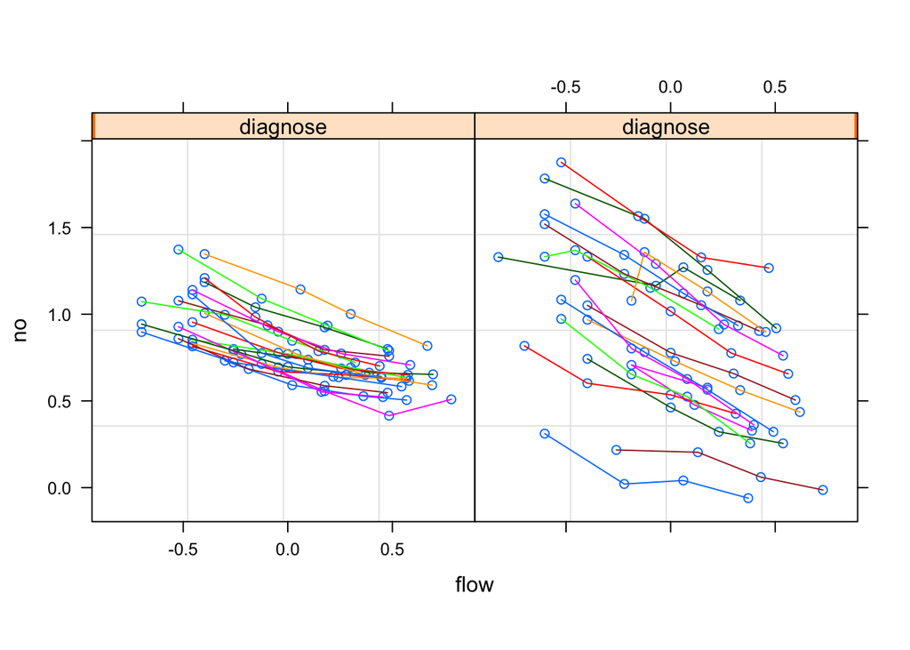

```r
# read in data
load(file = "no.Rdata")
# Make a groupedData object for the "trellis graphs" (spaghetti plot) per group
nogr <- nlme::groupedData(no ~ flow | num, data=nodat, outer = ~diagnose)
# spaghetti plot per group
plot(nogr, outer=~diagnose, key=F, aspect=1)
```

1. Describe what you see in the graphs. What would be your first intuition with respect to the research questions?
2. Fit a model with random intercept random slope regression for the healthy group. What is the mean slope and intercept? What are the estimated variances of the random components? Is a random slope model necessary, or would a random intercept be sufficient?
3. Answer the same questions for the group of children with asthma.
4. Compare the results of the two groups. What would you conclude on the basis of these results?
5. Fit a model for the two groups combined, using an interaction for diagnosis*flow and allowing a different covariance structure for the two groups (note: In R, use the following command:)

```r
no.lme.3 <- lme(no~flow + factor(diagnose)+ flow:factor(diagnose), random=~flow + diagnose + flow*diagnose| num,  weights=varIdent(form=~1|diagnose), method="ML", data=nodat)
```

The random command contains a term for group, flow and the group*flow interaction and thus allows for a separate variance for the random intercept and slope for the two diagnosis groups. The weights statement further allows differing residual variances for the two groups. Check that the log-likelihood of this model is the sum of the log-likelihoods of the models in b and c.

6. Can the variance structure be simplified by assuming equal residual variances? (Hint: try removing the weights statement.)
7. Can the covariance structure be further reduced? Try to simplify the random command by removing the diagnose*flow interaction, and then by removing diagnose.
8. Is the fixed diagnose*flow interaction necessary? In other words: do the asthmatic children indeed have a significantly more negative slope than the healthy children?
9. Answer the following questions for the model you end up with. What is the slope for the healthy group, what for the asthma group? What is the standard deviation of the random intercept the healthy children, and is the variance for asthmatic children larger or smaller? What is the residual standard deviation for the two groups?